# wk05_ggplot

Patricia Faundez

February 5, 2016

```r
wd = 'env-info_hw'

# set working directory for Console (vs Rmd)
if (wd %in% list.files() & interactive()){
    setwd(wd)
}

# ensure working directory
if (basename(getwd()) != wd){
  stop(sprintf("WHOAH! Your working directory is not in '%s'!\n   getwd(): %s", wd, getwd()))
}
```

# Metadata thin.txt

“varname” “descrip” “1” “startyear” “year of thin” “2” “thin” “percent canopy removed” “3” “postyears” “years since thinnning” “4” “day” “current day” “5” “month” “current month” “6” “trans” “transpiration (mm/day)” “7” “evap” “evaporation (mm/day)” “8” “lai” “Leaf Area” “9” “psn” “Photosynthesis (gC/m2/day)” “10” “cpool” “Non Structural Carbohydrate (gC/m2)” “11” “plantc” “Total Biomass (kgC/m2)” “12” “year” “year”

```r
getwd()
```

```
## [1] "C:/Users/Patricia/Box Sync/Winter_2016/Environmental_Informatics/faundez.github.io/env-info_hw"
```

```r
library(readr)
library(readxl) # install.packages('readxl')
library(tidyr)
library(httr)   # install.packages('httr')
#library(plyr)   # install.packages('plyr')
library(dplyr)
```

```r
library(ggplot2)
library(knitr)       # functions for knitting Rmd documents to html
library(RColorBrewer)
library(gridExtra)
```

# Everything in http://docs.ggplot2.org/current/

# Questions in Chunks: 3,19,42

# my task I explored Aesthetics, Lines specified by slope and intercept, geom_abline: slope and intercept

# Comparing Biomass with other variables

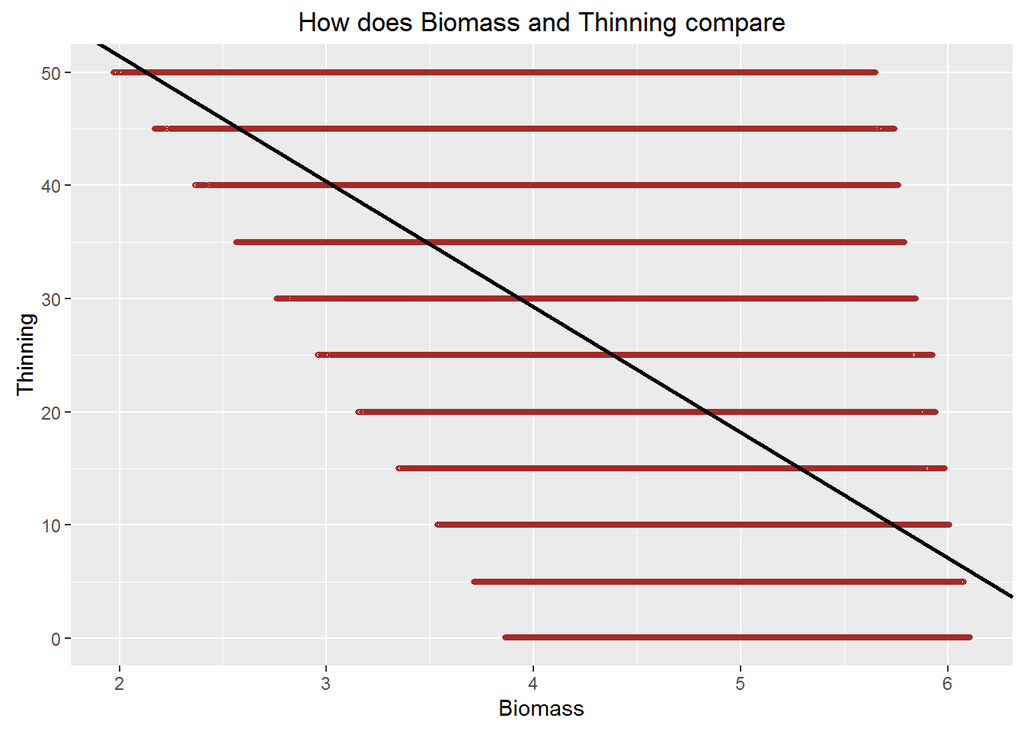

```r
thin <- read_csv("~/Winter_2016/Environmental_Informatics/faundez.github.io/env-info_hw/thin.csv")
#scatter plot Biomass v/s Thinning
p1=ggplot(thin, aes(x=plantc, y=thin))+geom_point(col="brown", shape=1, size=rel(1))
#How does Biomass and Thinning is compare
p1=p1+labs(x="Biomass", y="Thinning")
  p1 = p1+ ggtitle("How does Biomass and Thinning compare")
#coef(lm(thin ~ plantc, data = thin)) # Calculate slope and intercept of line of best fit
#p1 + geom_smooth(method = "lm", se = FALSE)                                  #NOT WORKING ????
p1 = p1 + geom_abline(intercept=73.59,slope=-11.08, colour="black", size=1)
p1
```

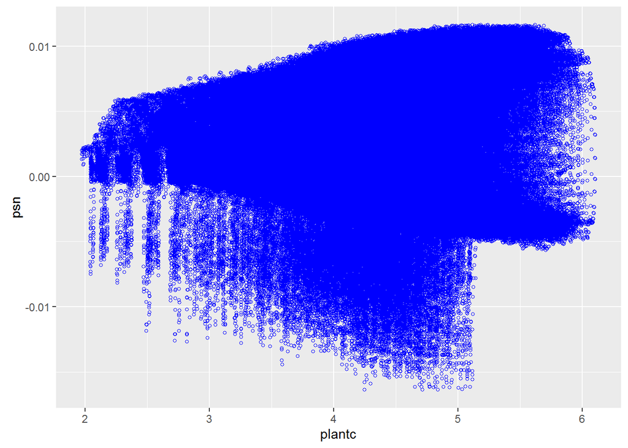

```r
#scatter plot Biomass v/s photosyntesis
p2=ggplot(thin, aes(x=plantc, y=psn))+geom_point(col="blue", shape=1, size=rel(1))
p2
```

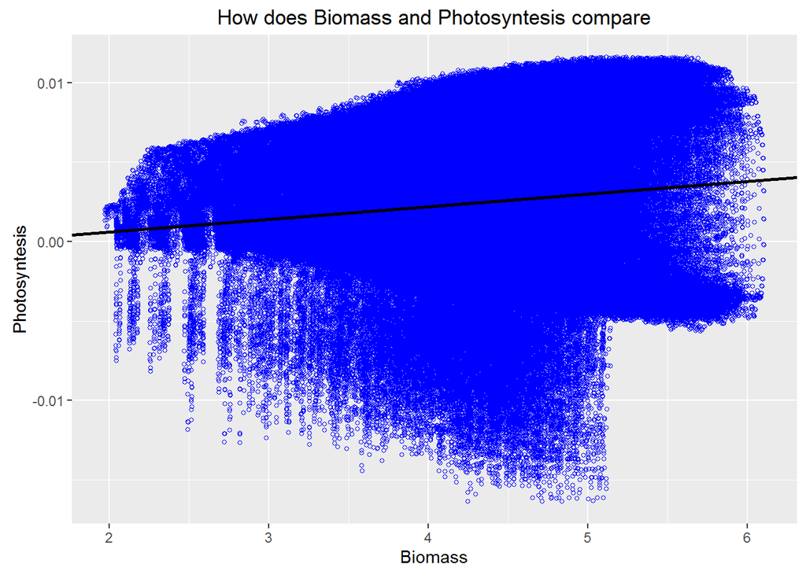

```r
#How does Biomass and Photosyntes is compare
p2=p2+labs(x="Biomass", y="Photosyntesis")
  p2 = p2+ ggtitle("How does Biomass and Photosyntesis compare")
#coef(lm(psn ~ plantc, data = thin)) # Calculate slope and intercept of line of best fit
  p2 = p2 + geom_abline(intercept=-0.001,slope=0.0008, colour="black", size=1)
p2
```

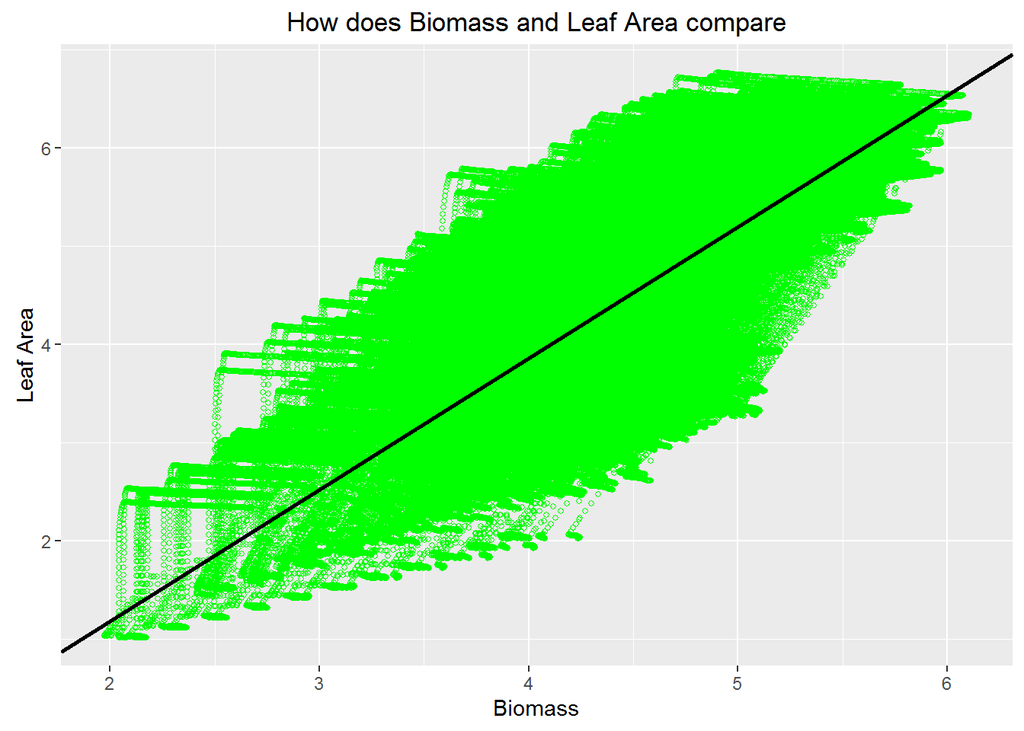

```r
#how does Leaf Area and Biomass compare
#scatter plot Leaf Area v/s Biomass
p3=ggplot(thin, aes(x=plantc, y=lai))+geom_point(col="green", shape=1, size=rel(1))
p3=p3+labs(x="Biomass", y="Leaf Area")
  p3 = p3+ ggtitle("How does Biomass and Leaf Area compare")
#coef(lm(lai ~ plantc, data = thin)) # Calculate slope and intercept of line of best fit
p3 = p3 + geom_abline(intercept=-1.5,slope=1.34, colour="black", size=1)
p3
```

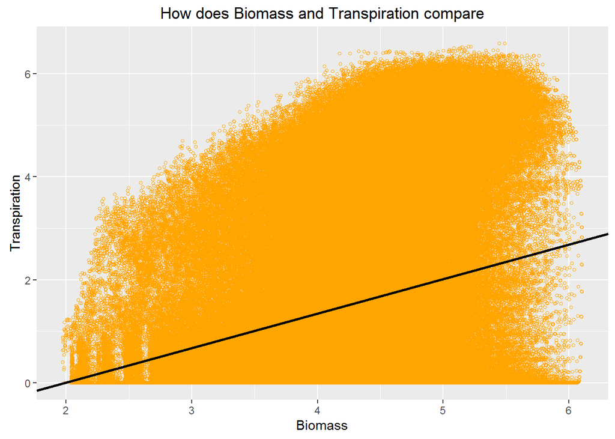

```r
#scatter plot Biomass v/s Transpiration
p4=ggplot(thin, aes(x=plantc, y=trans))+geom_point(col="orange", shape=1, size=rel(1))
#How does Biomass and Transpiration is compare
p4=p4+labs(x="Biomass", y="Transpiration")
  p4 = p4+ ggtitle("How does Biomass and Transpiration compare")
#coef(lm(trans ~ plantc, data = thin)) # Calculate slope and intercept of line of best fit
  p4 = p4 + geom_abline(intercept=-1.337,slope=0.67, colour="black", size=1)
p4
```

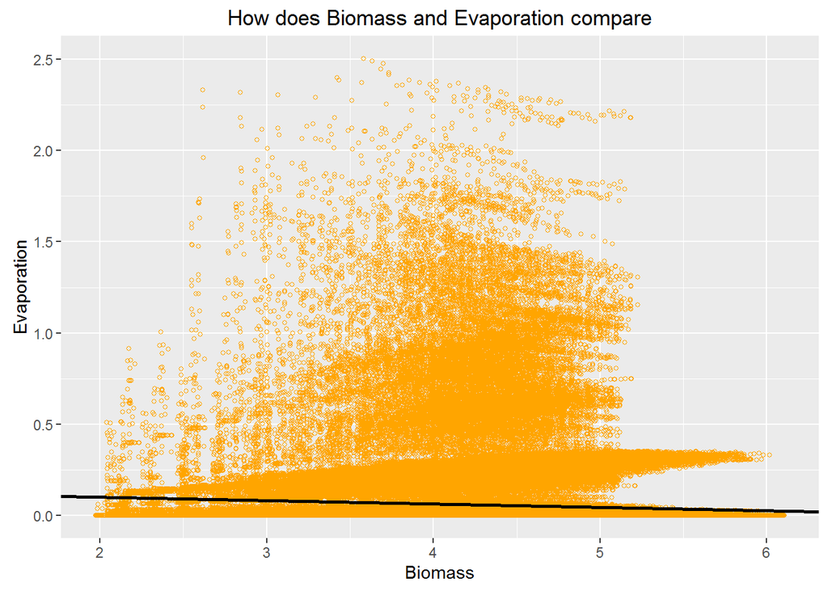

```r
#scatter plot Biomass v/s Evaporation
p5=ggplot(thin, aes(x=plantc, y=evap))+geom_point(col="orange", shape=1, size=rel(1))
#How does Biomass and Evaporation is compare
p5=p5+labs(x="Biomass", y="Evaporation")
  p5 = p5+ ggtitle("How does Biomass and Evaporation compare")
#coef(lm(evap ~ plantc, data = thin)) # Calculate slope and intercept of line of best fit
  p5 = p5 + geom_abline(intercept=0.14,slope=-0.019, colour="black", size=1)
p5
```

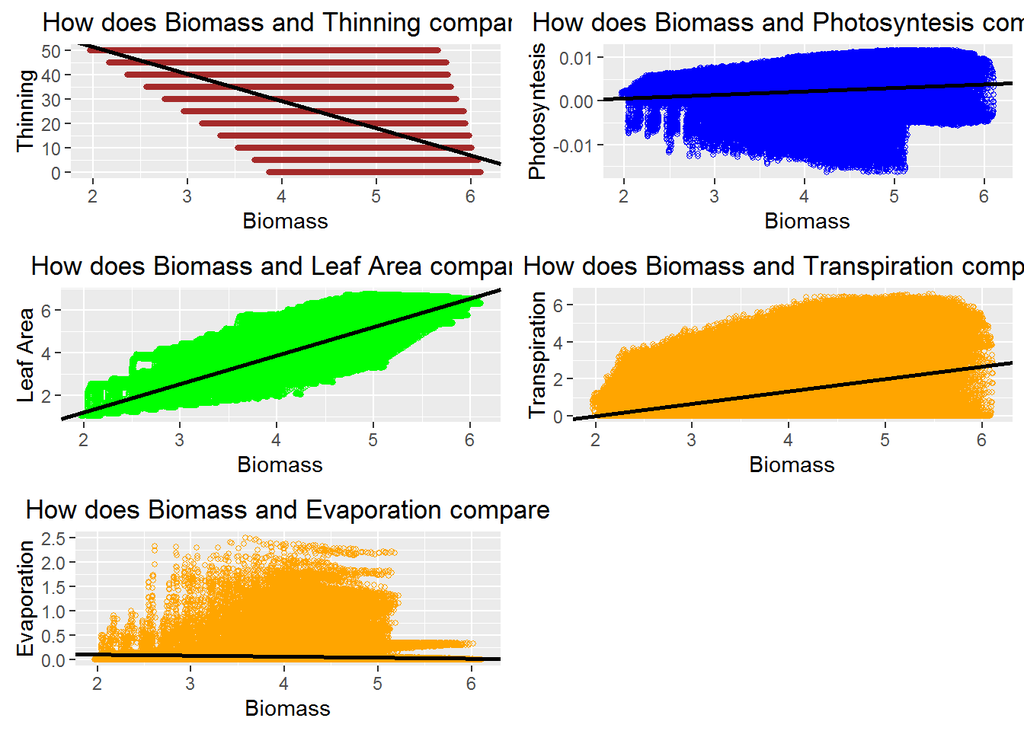

```r
grid.arrange(p1,p2,p3,p4,p5)
```